# iDEP: Investigating Differentially Expressed Genes

## If this site has contributed to your work, please cite our article:

Ge, S.X., Son, E.W. & Yao, R. iDEP: an integrated web application for differential expression and pathway analysis of RNA-Seq data. BMC Bioinformatics 19, 534 (2018). https://doi.org/10.1186/s12859-018-2486-6

## Summary

Read Counts data were analyzed using iDEP v2.4.4. The data was first filtered to remove reads below 0.5 CPM in at least 1 sample. Then the data was transformed with EdgeR using a pseudocount of 4. Missing values were imputed using geneMedian.

After mapping, there are 32833 unique genes in 158 samples. Of the 24127 genes passed filter, 24127 were converted to Ensembl/STRING gene IDs in our database. The remaining 0 genes were kept in the data using original IDs.

Differential expression analysis was performed using DESeq2 with an FDR cutoff of 0.1 and a minimum fold-change threshold of 2. Standard Wald test was used and independent filtering was enabled.

## Selected Comparison: Time_After_Treatment_min4320-Time_After_Treatment_min0

Up-regulated genes: 368

Down-regulated genes: 416

## Top Up-regulated Genes

```r
if (!is.null(params$up_genes_table) && nrow(params$up_genes_table) > 0) {
  kbl(params$up_genes_table, escape = FALSE) %>%
    kable_classic(full_width = FALSE, html_font = "Cambria")
} else {
  print("No up-regulated genes found for this comparison.")
}
```

| Symbol | Ensembl ID | log2 FC | Adj. P-value | Description |
| --- | --- | --- | --- | --- |
| LpxC5 | AT1G25210 | 15.664 | 2.58e-11 | UDP-3-O-acyl N-acetylglycosamine deacetylase family protein |
| AT2G09785 | AT2G09785 | 15.549 | 6.43e-03 | NcRNA |
| AT1G05767 | AT1G05767 | 11.938 | 6.33e-08 | S-adenosyl-L-methionine-dependent methyltransferases superfamily protein |
| MRD1 | AT1G53480 | 10.768 | 1.44e-05 | Mto 1 responding down 1 |
| CRU3 | AT4G28520 | 10.720 | 1.84e-03 | Cruciferin 3 |
| AT1G07500 | AT1G07500 | 10.459 | 1.98e-06 | Uncharacterized protein |
| NUDT24 | AT5G19470 | 6.310 | 8.84e-04 | Nudix hydrolase homolog 24 |
| PAP14 | AT2G46880 | 5.297 | 3.78e-02 | Purple acid phosphatase 14 |
| ATEXO70G2 | AT1G51640 | 5.260 | 9.01e-02 |  |
| NIMIN1 | AT1G02450 | 5.100 | 1.56e-03 | NIM1-interacting 1 |
| AT1G05187 | AT1G05187 | 5.041 | 3.34e-02 | NcRNA |
| ANK | AT5G54610 | 4.809 | 5.25e-04 | Ankyrin |
| AT3G51070 | AT3G51070 | 4.727 | 7.53e-02 | S-adenosyl-L-methionine-dependent methyltransferases superfamily protein |
| AT5G15500 | AT5G15500 | 4.440 | 2.34e-03 | Ankyrin repeat family protein |
| AT2G04515 | AT2G04515 | 4.421 | 9.36e-04 | Uncharacterized protein |
| AT4G01985 | AT4G01985 | 4.294 | 7.11e-02 | Uncharacterized protein |
| AT5G03350 | AT5G03350 | 4.287 | 2.72e-05 | Legume lectin family protein |
| AT1G05837 | AT1G05837 | 4.215 | 6.24e-02 | NcRNA |
| WRKY38 | AT5G22570 | 4.201 | 3.63e-04 | WRKY DNA-binding protein 38 |
| HB21 AT2G18550 | AT2G18550 | 4.138 | 2.83e-03 | Homeobox protein 21 |
| PCR1 | AT1G14880 | 4.099 | 1.44e-02 | PLANT CADMIUM RESISTANCE 1 |
| PCC1 | AT3G22231 | 4.063 | 1.15e-02 | Pathogen and circadian controlled 1 |
| CRK24 | AT4G23320 | 4.042 | 2.08e-04 | Cysteine-rich RLK (RECEPTOR-like protein kinase) 24 |
| RK1 | AT1G65790 | 3.909 | 4.98e-03 | Receptor kinase 1 |
| AT3G02910 | AT3G02910 | 3.855 | 1.66e-02 | AIG2-like (avirulence induced family protein |
| AT3G22235 | AT3G22235 | 3.805 | 1.88e-04 | Cysteine-rich TM module stress tolerance protein |
| RLP38 | AT3G23120 | 3.785 | 1.14e-03 | Receptor like protein 38 |
| AT3G05845 | AT3G05845 | 3.784 | 1.50e-03 | NcRNA |
| AT1G13470 | AT1G13470 | 3.639 | 3.73e-03 |  |
| AT1G62420 | AT1G62420 | 3.609 | 9.65e-03 | DUF506 family protein (DUF506) |
| AT4G12495 | AT4G12495 | 3.597 | 5.42e-02 | Uncharacterized protein |
| AT3G48640 | AT3G48640 | 3.543 | 1.96e-02 | Uncharacterized protein |
| AT2G05155 | AT2G05155 | 3.510 | 4.76e-02 | NcRNA |
| LURP1 | AT2G14560 | 3.463 | 3.27e-02 | LURP-one-like protein (DUF567) |
| CRK37 | AT4G04500 | 3.324 | 4.18e-02 | Cysteine-rich RLK (RECEPTOR-like protein kinase) 37 |
| AT5G06505 | AT5G06505 | 3.268 | 2.65e-02 | NcRNA |
| AT1G31920 | AT1G31920 | 3.262 | 2.44e-04 | Tetratricopeptide repeat (TPR)-like superfamily protein |
| AT5G02865 | AT5G02865 | 3.247 | 9.29e-03 | NcRNA |
| AT1G08657 | AT1G08657 | 3.187 | 1.14e-02 | NcRNA |
| WAK3 | AT1G21240 | 3.170 | 6.02e-02 | Wall associated kinase 3 |
| AT5G26690 | AT5G26690 | 3.169 | 2.46e-02 | Heavy metal transport/detoxification superfamily protein |
| AT3G60470 | AT3G60470 | 3.157 | 3.31e-02 | Transmembrane protein, putative (DUF247) |
| BG3 | AT3G57240 | 3.149 | 5.50e-02 | Beta-1,3-glucanase 3 |
| AT4G14819 | AT4G14819 | 3.130 | 2.06e-02 |  |
| AT5G53230 | AT5G53230 | 3.119 | 8.80e-02 |  |
| AT5G37940 | AT5G37940 | 3.110 | 4.72e-02 | Zinc-binding dehydrogenase family protein |
| AT1G19960 | AT1G19960 | 3.095 | 6.71e-05 | Transcription factor |
| AT3G28510 | AT3G28510 | 3.077 | 6.77e-02 | P-loop containing nucleoside triphosphate hydrolases superfamily protein |
| WRKY54 | AT2G40750 | 3.017 | 2.30e-04 | WRKY DNA-binding protein 54 |
| WAK1 | AT1G21250 | 3.010 | 1.36e-04 | Cell wall-associated kinase |

## Top Down-regulated Genes

```r
if (!is.null(params$down_genes_table) && nrow(params$down_genes_table) > 0) {
  kbl(params$down_genes_table, escape = FALSE) %>%
    kable_classic(full_width = FALSE, html_font = "Cambria")
} else {
  print("No down-regulated genes found for this comparison.")
}
```

| Symbol | Ensembl ID | log2 FC | Adj. P-value | Description |
| --- | --- | --- | --- | --- |
| AT1G05562 | AT1G05562 | -28.254 | 1.88e-04 | NcRNA |
| ATCG01000 | ATCG01000 | -25.179 | 5.14e-08 |  |
| AT1G68250 | AT1G68250 | -18.968 | 1.57e-13 | Uncharacterized protein |
| AT5G01645 | AT5G01645 | -16.743 | 2.38e-09 | NcRNA |
| AT3G44435 | AT3G44435 | -13.045 | 9.23e-02 | Uncharacterized protein |
| GMD1 | AT5G66280 | -11.730 | 3.18e-10 | GDP-D-mannose 4,6-dehydratase 1 |
| AT5G42825 | AT5G42825 | -7.966 | 5.97e-03 | Uncharacterized protein |
| AT1G22810 | AT1G22810 | -6.027 | 7.88e-03 | Integrase-type DNA-binding superfamily protein |
| AT1G32910 | AT1G32910 | -5.925 | 1.89e-03 | HXXXD-type acyl-transferase family protein |
| RRTF1 | AT4G34410 | -5.673 | 1.21e-03 | Redox responsive transcription factor 1 |
| CWLP | AT3G22120 | -5.654 | 1.83e-10 | Cell wall-plasma membrane linker protein |
| AT5G28237 | AT5G28237 | -5.620 | 2.14e-03 | Pyridoxal-5’-phosphate-dependent enzyme family protein |
| LpxC4 | AT1G25145 | -5.617 | 3.43e-02 | UDP-3-O-acyl N-acetylglycosamine deacetylase family protein |
| AT1G76640 | AT1G76640 | -5.242 | 3.46e-04 | Calcium-binding EF-hand family protein |
| MSRB7 | AT4G21830 | -4.998 | 1.75e-13 | Methionine sulfoxide reductase B7 |
| LEA | AT2G21490 | -4.932 | 6.72e-02 | Dehydrin LEA |
| AT1G19620 | AT1G19620 | -4.926 | 2.09e-06 | Uncharacterized protein |
| JAZ7 | AT2G34600 | -4.828 | 4.99e-05 | Jasmonate-zim-domain protein 7 |
| AT3G22275 | AT3G22275 | -4.781 | 1.94e-02 | Jasmonate ZIM-domain protein |
| WRKY40 | AT1G80840 | -4.732 | 4.40e-07 | WRKY DNA-binding protein 40 |
| AT1G08003 | AT1G08003 | -4.709 | 3.19e-02 | NcRNA |
| AT1G04183 | AT1G04183 | -4.620 | 7.28e-03 | NcRNA |
| ATOEP16-2 | AT4G16160 | -4.340 | 1.66e-02 | Mitochondrial import inner membrane translocase subunit Tim17/Tim22/Tim23 family protein |
| AT1G05927 | AT1G05927 | -4.307 | 3.47e-02 | NcRNA |
| AT5G51190 | AT5G51190 | -4.205 | 7.26e-02 | Integrase-type DNA-binding superfamily protein |
| AT1G33760 | AT1G33760 | -4.189 | 1.98e-02 | Integrase-type DNA-binding superfamily protein |
| DDF1 | AT1G12610 | -4.169 | 4.81e-02 | Integrase-type DNA-binding superfamily protein |
| AT2G30830 | AT2G30830 | -3.929 | 4.18e-03 | 2-oxoglutarate (2OG) and Fe(II)-dependent oxygenase superfamily protein |
| AT1G21280 | AT1G21280 | -3.817 | 5.68e-08 | Copia-like polyprotein/retrotransposon |
| DIN11 | AT3G49620 | -3.731 | 9.41e-05 | 2-oxoglutarate (2OG) and Fe(II)-dependent oxygenase superfamily protein |
| CYP94B1 | AT5G63450 | -3.680 | 4.89e-10 | Cytochrome P450, family 94, subfamily B, polypeptide 1 |
| AT1G15330 | AT1G15330 | -3.664 | 6.99e-02 | Cystathionine beta-synthase (CBS) protein |
| AT2G38240 | AT2G38240 | -3.649 | 9.30e-02 | 2-oxoglutarate (2OG) and Fe(II)-dependent oxygenase superfamily protein |
| ERF13 | AT2G44840 | -3.606 | 3.49e-04 | Ethylene-responsive element binding factor 13 |
| JAZ8 | AT1G30135 | -3.584 | 4.12e-02 | Jasmonate-zim-domain protein 8 |
| MDHAR | AT3G09940 | -3.572 | 2.58e-11 | Monodehydroascorbate reductase |
| JAZ5 | AT1G17380 | -3.444 | 8.38e-07 | Jasmonate-zim-domain protein 5 |
| ZAT7 | AT3G46090 | -3.423 | 1.94e-03 | C2H2 and C2HC zinc fingers superfamily protein |
| MAPKKK21 | AT4G36950 | -3.399 | 2.38e-02 | Mitogen-activated protein kinase kinase kinase 21 |
| AT3G09870 | AT3G09870 | -3.389 | 2.94e-02 | SAUR-like auxin-responsive protein family |
| CYP94C1 | AT2G27690 | -3.376 | 2.53e-04 | Cytochrome P450, family 94, subfamily C, polypeptide 1 |
| AT4G27654 | AT4G27654 | -3.364 | 5.59e-02 | Uncharacterized protein |
| RAP2.6 | AT1G43160 | -3.335 | 3.46e-05 | Uncharacterized protein |
| AT1G58223 | AT1G58223 | -3.305 | 2.55e-03 | Uncharacterized protein |
| AT5G06235 | AT5G06235 | -3.281 | 3.25e-02 | NcRNA |
| OFP14 | AT1G79960 | -3.229 | 1.28e-02 | Ovate family protein 14 |
| OPT2 | AT1G09930 | -3.206 | 2.63e-02 | Oligopeptide transporter 2 |
| CBF1 | AT4G25490 | -3.201 | 3.69e-02 | C-repeat/DRE binding factor 1 |
| AT2G08060 | AT2G08060 | -3.138 | 4.28e-03 | NcRNA |
| HSP17.6II | AT5G12020 | -3.102 | 4.95e-02 | 17.6 kDa class II heat shock protein |

## DEG Heatmap

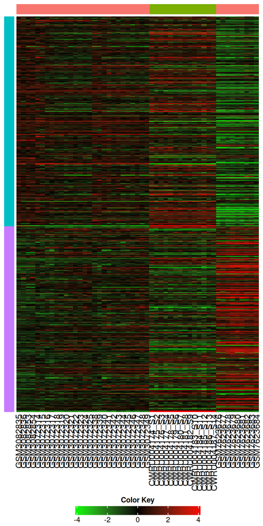

```r
if (!is.null(params$heat_data) && !is.null(params$heat_bar)) {
  heat_colors <- unlist(strsplit(params$heatmap_color_select, "-"))

  deg_heatmap(
    df = params$heat_data,
    bar = params$heat_bar,
    heatmap_color_select = heat_colors,
    cluster_rows = FALSE
  )
}
```

## Volcano Plot

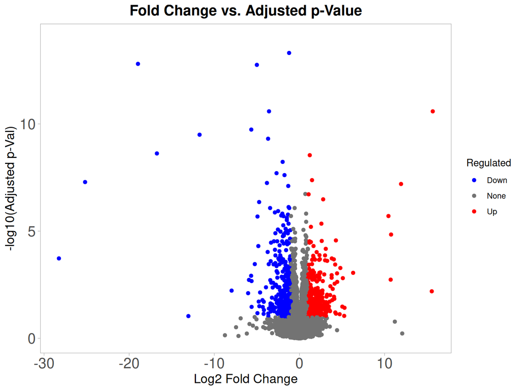

```r
if (!is.null(params$vol_data) && !is.null(params$vol_data$data)) {
  p <- plot_volcano(
    data = params$vol_data$data,
    plot_colors = params$plot_colors,
    anotate_genes = params$gene_labels_volcano
  )
  p <- refine_ggplot2(
    p = p,
    gridline = params$plot_grid_lines,
    ggplot2_theme = params$ggplot2_theme
  )
  print(p)
}
```